# Data Driven Student Support

Elisabeth Lackner and Patrick Wynne

November 20, 2017

## Overview

- Objective
- Data Elements
- Data Flow
- Predictive Analytics
- Dashboard & Actions Taken
- Outcome
- Next Steps

## Question

- Can timely data monitoring increase student success for first-time full-time freshmen?

## Objective

- The objective was to establish a daily updated dashboard with student data that would allow targeted outreach to students
- In a campus wide effort, Institutional Research, IT, Student Affairs, Institutional Effectiveness, and Registrar met regularly throughout the summer and fall of 2016 to discuss interventions for the Fall 2016 first-time full-time cohort

## Data Needs

- The team decided to focus energy on the following areas
1. College Readiness
2. Early Alert
3. Academic Engagement
4. Student Information

## College Readiness

- An emphasis was placed on what we know about students before they arrive on campus
- High school GPA
- Remedial needs in math, reading, and/or writing

## Early Alert - Starfish

- Queensborough Community College rolled out Starfish in Fall 2013
- Starfish allows us to monitor:
- Tracking items in the form of flags, referrals, and kudos
- Tutoring appointments at learning centers
- And more recently advising appointments

## Student Information/Demographics

- With advisors in mind as possible end users, we included basic student information including
- Name
- Student ID
- Gender
- Ethnicity

## College Engagement

- Major and Academy
- Accelerated Study in Associate Programs (ASAP) status
- Enrolled in writing intensive
- Enrolled in Intro to College Freshman seminar
- Course withdrawals
- Withdrawal from the college

## Data Flow

[figure not shown]

## Extract, Transform, and Load (ETL)

- The data needed for the project lives in different places
- For the project to be successful we needed an ETL process to extract the data from the various locations, transform the data as needed, and load the data to where it will be read by tableau
- We used a .csv file on our shared hard-drive to act as a data store
- Wrote an R script that reads from our SIS system and Oracle database were we keep our learning center reports and import our Starfish tracking items.

## R Environment

- Below is an image of the R session environment we used to gather our data

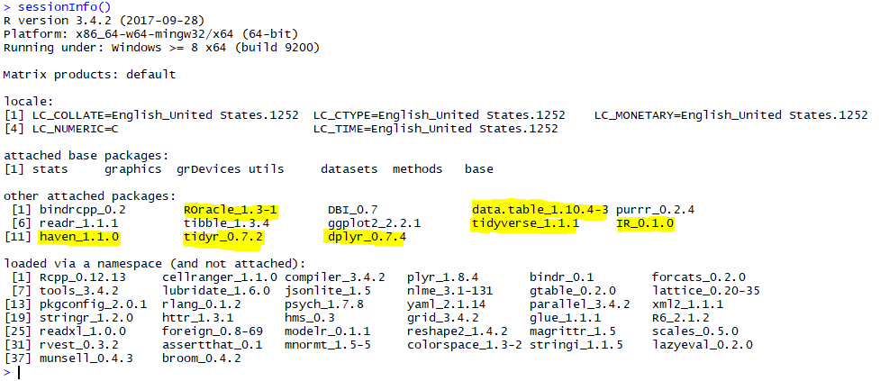

## Predictive Analytics

- Using these variables, we created a statistical model to predict next semester retention
- The purpose of the statistical model was two-fold:
1. Identify students who were unlikely to return the next semester and provide an intervention
2. Better understand risk factors for attrition

## Decision Trees

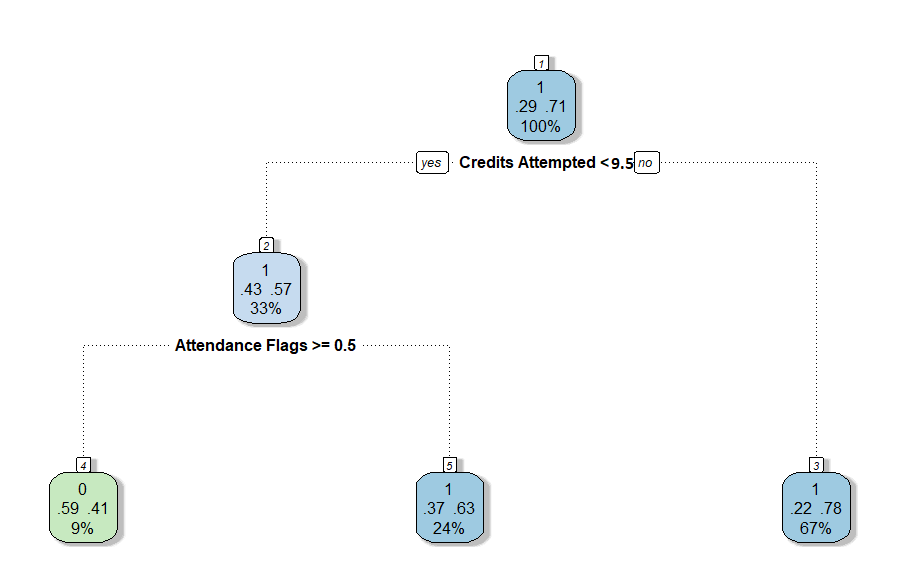

## Model

- We used gradient boosting via XGBoost
- Ensemble of 800 decisions trees
- Each tree has a max depth of 4 branches
- Each tree samples 25% of cases
- Each tree samples 25% of the variables

## Model Performance Testing

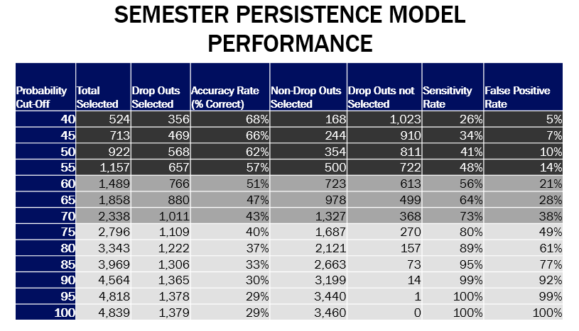

## ROC Curve

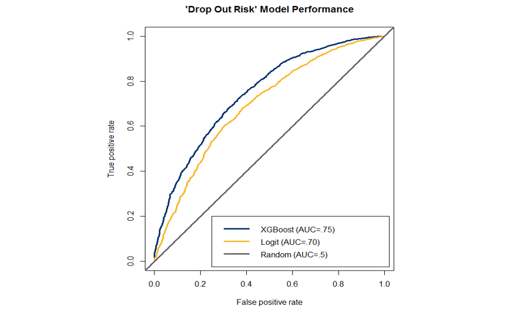

## Key Risk Factors

- Starfish Early Alerts: Attendance Concern
- Number of tutoring visits and visit type
- Number of credits attemtped

## Dashboard

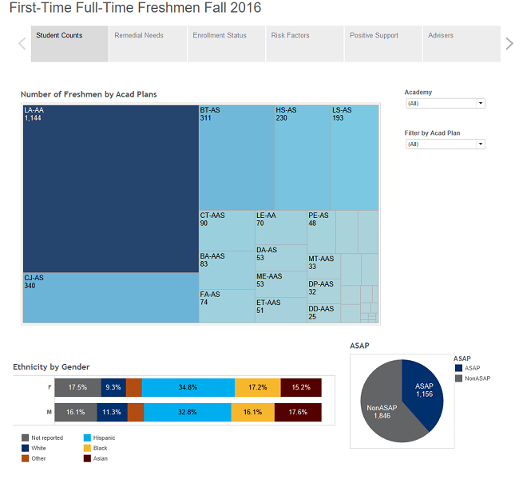

## Dashboard

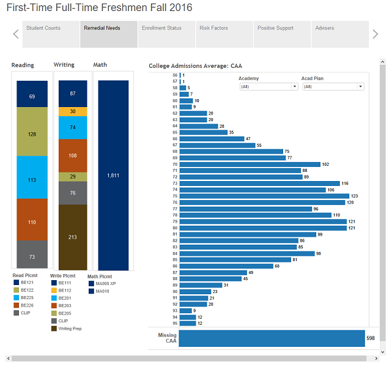

## Dashboard

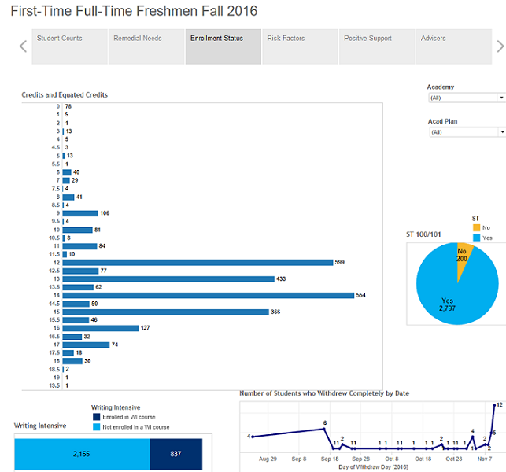

## Dashboard

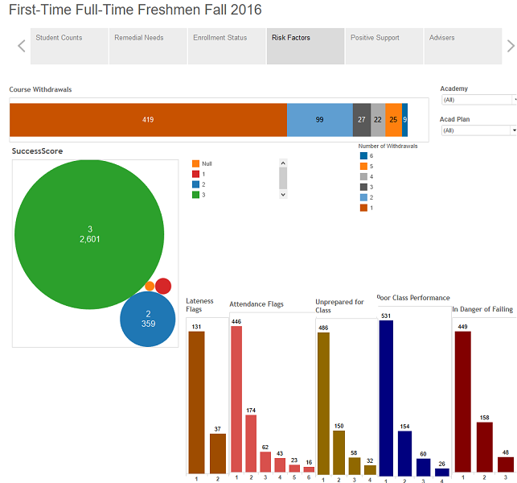

## Dashboard

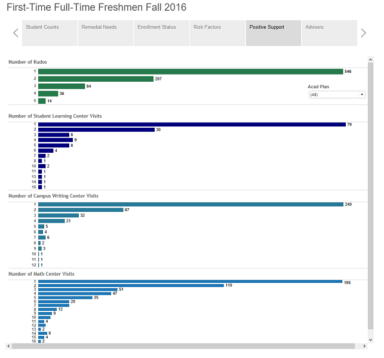

## Actions taken

- Advisors receive lists of students with contact information who displayed risky behavior
1. Required to take remedial math but didn’t enroll
2. Were not enrolled in Intro to College Freshman Seminar
3. Had a success score of 1 or 2 (based on internal rentention prediction model)

## Outcomes

- One-semester retention
- Profile of students who left
- One-year retention

## One-semester retention

- By spring 2017, 509 or 17% of the 2,998 first-time full-time fall 2016 freshmen dropped out.

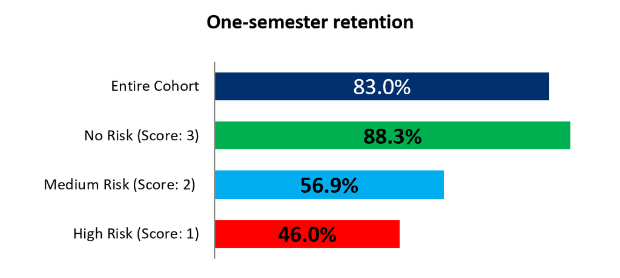

## How did drop-outs differ from those who were retained?

- Over 50% of dropouts had one or more Early Alert attendance flag.

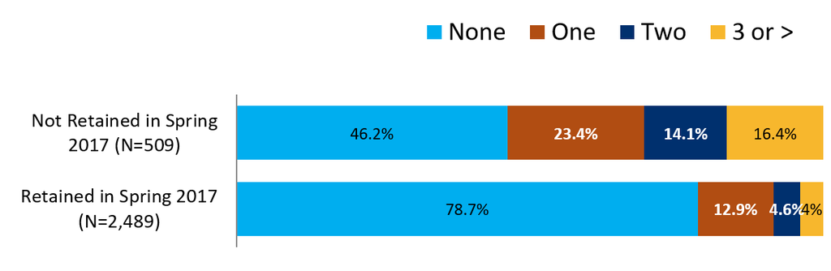

## How did drop-outs differ from those who were retained?

- Only 17% of dropouts had one or more tutoring sessions compared to 35% of retained freshmen.

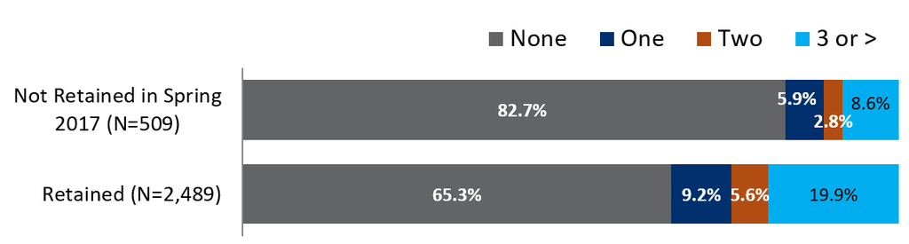

## How did drop-outs differ from those who were retained?

- 31% of dropouts had one or more Kudos compared to 41% of retained freshmen.

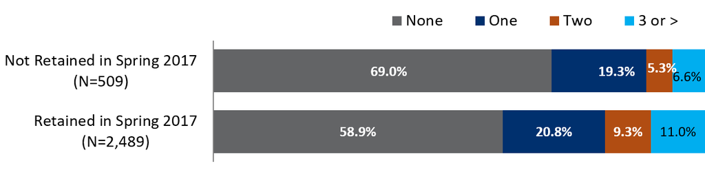

## How did drop-outs differ from those who were retained?

- Dropouts withdrew more often from courses

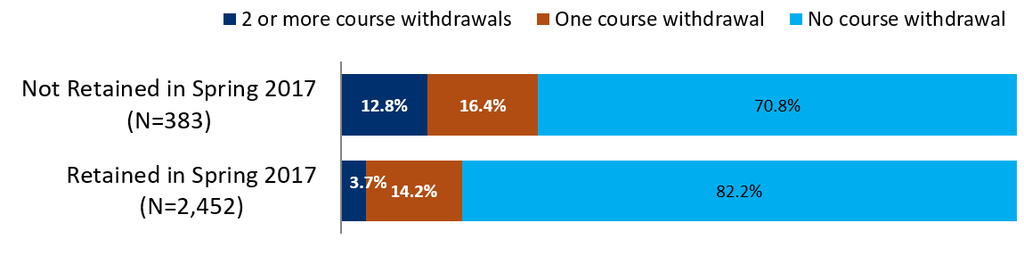

## How did drop-outs differ from those who were retained?

- Over 55% of dropouts were on academic probation.

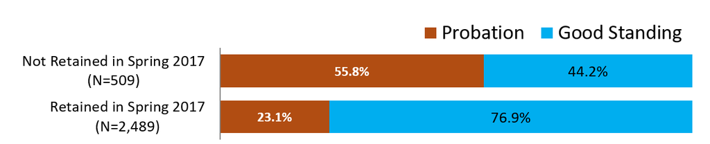

## One-year retention

- All 2,489 freshmen who returned in spring 2017 had received academic advising before the start of the spring 2017 term. However, no further ongoing data monitoring was performed and no additional risk scores were calculated for these students.
- Advisers continued to utilized Starfish to reach out to students with flags and tutoring referrals.
- Students on academic probation participated in a two hour academic success workshop.

## One-year retention

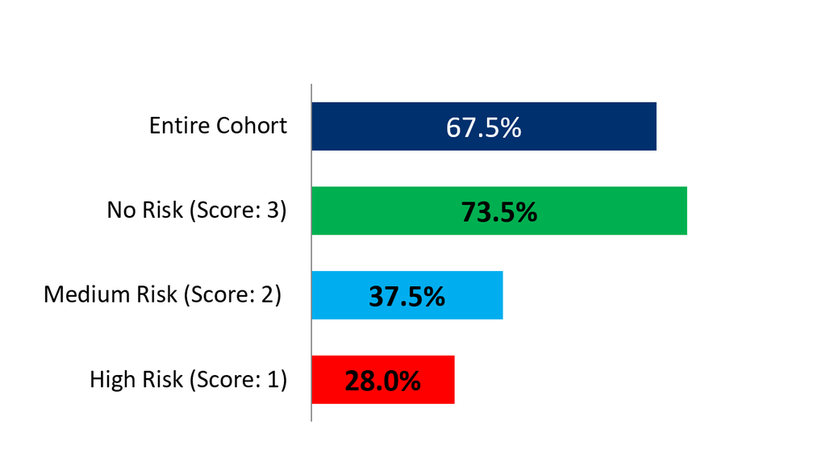

## Next Steps

- Our pilot effort last fall led to more investment from the ground up
- IT and IR are collaborating to create a local data warehouse with a daily ETL refresh
- OBIEE is connected to the data warehouse and will be used as the front-end for our future reports and dashboards

## Next Steps

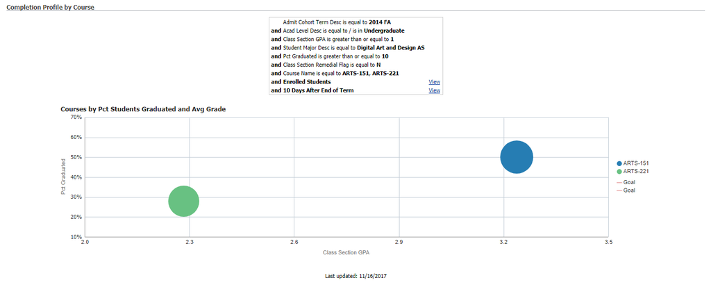

## Questions?

Elisabeth Lackner  
Director of Institutional Research and Assessment  
ELackner@qcc.cuny.edu  
718-631-6279  
Patrick Wynne  
Institutional Research Specialist  
PWnne@qcc.cuny.edu  
718-631-6279